# Investigation of Bike Trips in San Francisco Bay area

## Anžela Filomena Minosi

## Investigation Overview

> In this investigation, I'm most interested in figuring out what features are best for predicting when a bike ride will most likely take place and what affects the duration of a bike ride. In particular, I'm going to take the following influences into account: start time, customers as well as the stations.

## Distribution of Duration in Seconds

> The duration in seconds ranges from 6 seconds up to 86,000 seconds just for a single trip. As this dataset is logarithmic in nature, so is the duration in seconds with a highly skewed data to the right.

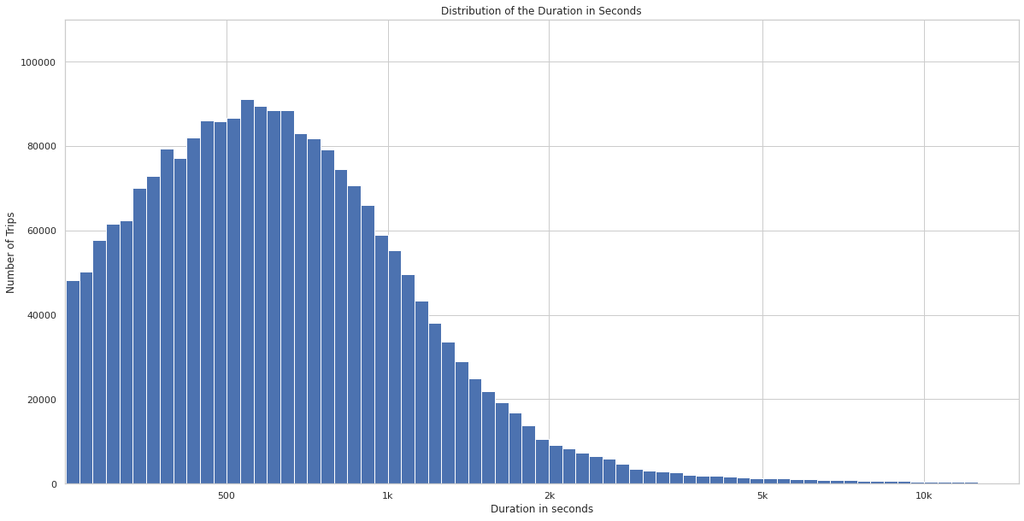

## Distribution of the Start Hour

> The distribution of the hour at which users of the bike-sharing company started a trip, takes on the shape of a curve. It shows that most trips were taken in the morning or between late afternoon and early evening hours.

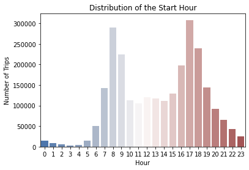

## Duration in Seconds vs Hour

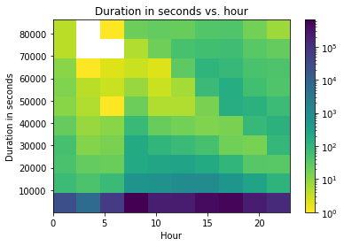

## Duration by Hours and Customers

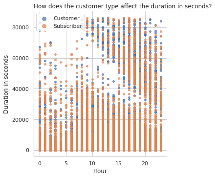

## Distribution of the Start Station ID

> The chart about the distribution of the start station ids is asymmetrically formed because it's skewed to the right. This applies to the distribution of the end station ids, too. That's why the difference in start and end station ids is quite small in general. It might be due to the fact that bike trips were just short trips or more likely that pick up and return station were often the same or nearby.

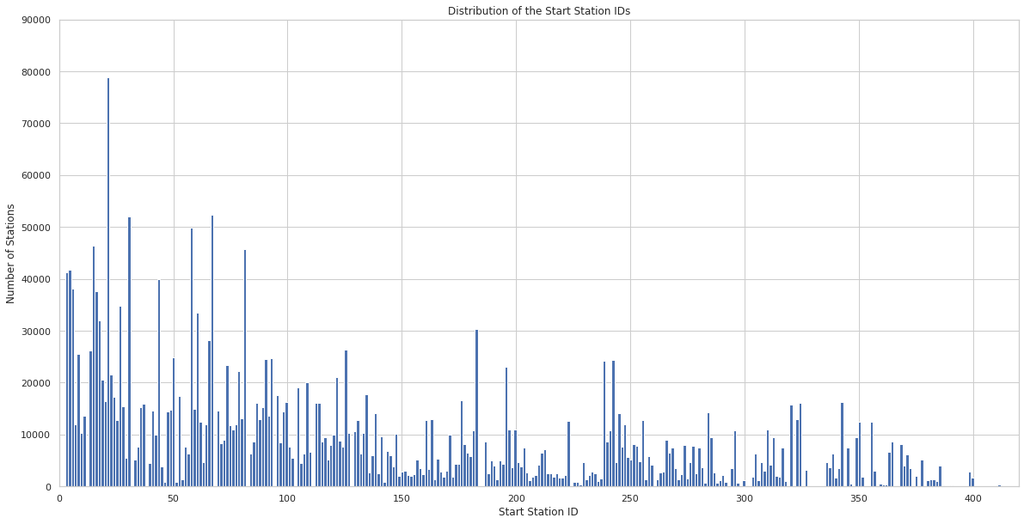

## Duration vs. Difference in Stations

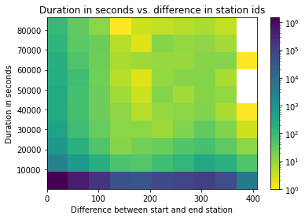

## Duration by Start Stations and Customers

> As pointed out previously, that a small difference in station ids increases the duration in seconds. This is still valid, when looking at start station ids. Both customer types started their bike rides at stations with ids < 150 mostly. But customers had longer bike rides than subscribers in general.

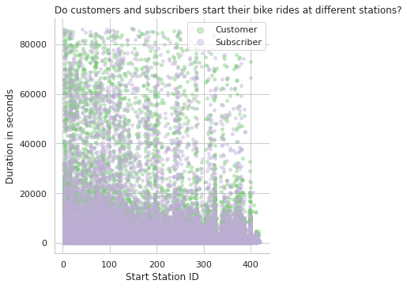

## Distribution of the Weekdays

> Another important time factor seemed to be the weekdays on which the bike trips start. This diagram isn't symmetrically formed but rather skewed. Basically, the most busiest days are Tuesday and Thursday as for this dataset.

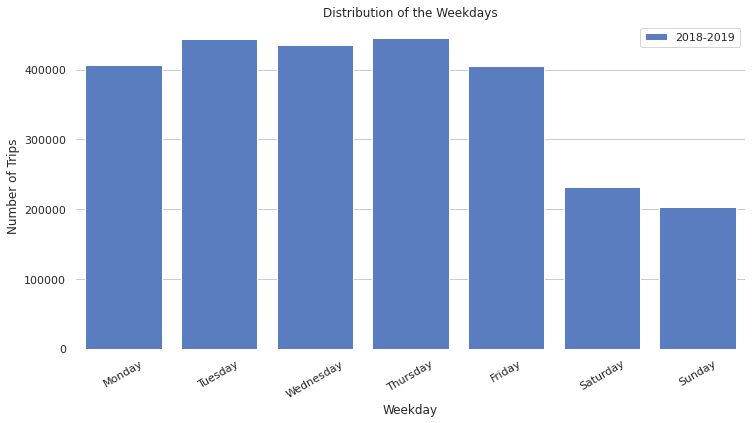

## Start Stations vs. Weekdays

> In dealing with large amount of data, the relationship between start stations ids and weekdays can be depicted in the form of a violin plot. This violin plot primarily answers the question: **How busy are the stations on each day of the week?** The answer is that, while during the work week the stations with an id < 150 are very busy, on the weekends however also the higher ids are well frequented.

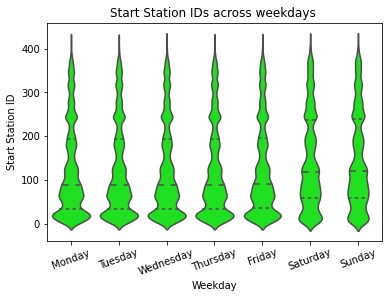

## Duration by Weekday and Customers

> If looking at the duration in seconds by taking the weekdays and the customers into account, it becomes clear that the mean of the duration in seconds highly depends on the day of the week as well as the user type. Customers who started their trips on weekends had longer trips on average compared to subscribers who rented their bikes for a much shorter period of time.

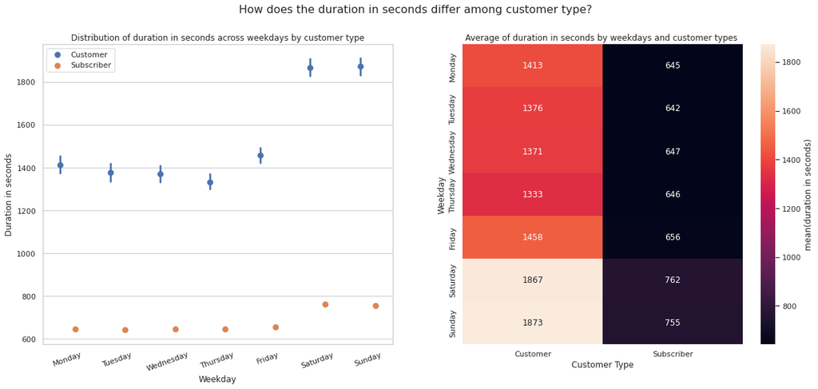